# **US Mass Shootings Analysis and Visualizations**

Derry Xu, Jackie Rambo, Stanley Chi, Zihao Zhang

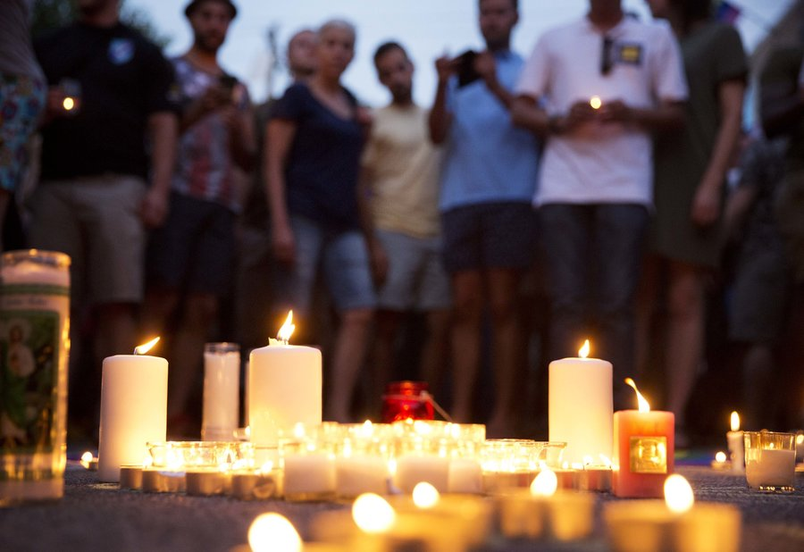

# **Introduction**

For our Final Project, we cleaned three datasets in RStudio with regular expression and loops, using the *US Mass Shootings*, *US States* and *DHS City Location Example* datasets that are downloaded from data.world/awram, data.world/markmarkoh and data.world/bryon, respectively. Using shiny app from RStudio and the Tableau software, we visualize the relations between mass shootings in the US, race of the shooters, numbers of fatalities and victims, and the location types. In the Mass Shootings dataset, mass shootings are defined by events with more than four victims, excluding robbery and gang violence incidents, from 1982 to 2015.

# **Dataset**

### **Accessing raw dataset from the *data.world***

From these urls: *US Mass Shootings* https://data.world/awram/us-mass-shootings, *US State Table* https://data.world/markmarkoh/us-state-table, *DHS City Location Example* https://data.world/bryon/dhs-city-location-example, we download our raw datasets and access them by queries through *data.world* server.

### **Download cleaned dataset from *data.world***

# **Data Cleaning**

```r
readLines("../01 Data/ETL.R")
```

```
incomplete final line found on '../01 Data/ETL.R'
```

```
  [1] "require(readr)"
  [2] "require(plyr)"
  [3] "require(dplyr)"
  [4] "require(stringr)"
  [5] "require(formattable)"
  [6] "require(data.world)"
  [7] ""
  [8] "MassShooting <- query("
  [9] "  data.world(propsfile = \"../02 Shiny/www/.data.world\"),"
 [10] "  dataset=\"awram/us-mass-shootings\", type=\"sql\","
 [11] "  query=\"SELECT YEAR as Year, `CASE` as `Case`, GENDER as Gender, RACE as Race,"
 [12] "         LOCATION as City, STATE as State, LOCATIONTYPE as LocationType,"
 [13] "         FATALITIES as Fatalities, WOUNDED as Wounded, TOTALVICTIMS as TotalVictims, NUMWEAPONS as NumWeapons,"
 [14] "         PRIORSIGNSOFMENTALILLNESS as MentalIllness, WEAPONSOBTAINEDLEGALLY as LegalWeapon"
 [15] "         from Sheet1\")"
```

[output cut: 117 more lines]

### **A Summary of Dataset**

```r
print(summary(MassShooting))
```

```
      Year          Case              Gender              Race               City
 Min.   :1982   Length:69          Length:69          Length:69          Length:69
 1st Qu.:1994   Class :character   Class :character   Class :character   Class :character
 Median :2005   Mode  :character   Mode  :character   Mode  :character   Mode  :character
 Mean   :2002
 3rd Qu.:2011
 Max.   :2015
    State           LocationType         Fatalities        Wounded        TotalVictims
 Length:69          Length:69          Min.   : 4.000   Min.   : 0.000   Min.   : 5.00
 Class :character   Class :character   1st Qu.: 5.000   1st Qu.: 1.000   1st Qu.: 7.00
 Mode  :character   Mode  :character   Median : 6.000   Median : 4.000   Median :11.00
                                       Mean   : 8.159   Mean   : 7.391   Mean   :15.55
                                       3rd Qu.: 9.000   3rd Qu.: 8.000   3rd Qu.:19.00
                                       Max.   :33.000   Max.   :58.000   Max.   :70.00
   NumWeapons    MentalIllness      LegalWeapon
 Min.   :1.000   Length:69          Length:69
 1st Qu.:1.000   Class :character   Class :character
 Median :2.000   Mode  :character   Mode  :character
 Mean   :2.217
 3rd Qu.:3.000
 Max.   :9.000
```

```r
print(summary(StateAbbrev))
```

```
    State           Abbreviation
 Length:51          Length:51
 Class :character   Class :character
 Mode  :character   Mode  :character
```

```r
print(summary(LatLong))
```

```
     City              State              Latitude       Longitude
 Length:37938       Length:37938       Min.   :17.71   Min.   :-176.66
 Class :character   Class :character   1st Qu.:35.16   1st Qu.: -97.94
 Mode  :character   Mode  :character   Median :39.47   Median : -89.77
                                       Mean   :38.88   Mean   : -91.99
                                       3rd Qu.:42.33   3rd Qu.: -81.34
                                       Max.   :71.29   Max.   : 178.88
```

### **The Dimensions of Dataset**

```r
print(head(MassShooting[MSdimensions]))
```

| Case | Gender | Race | City | State | LocationType | MentalIllness | LegalWeapon |
| --- | --- | --- | --- | --- | --- | --- | --- |
| Chattanooga military recruitment center | Male | Middle Eastern | Chattanooga | Tennessee | Military | true | true |
| Charleston Church Shooting | Male | White | Charleston | South Carolina | Religious | false | true |
| Accent Signage Systems shooting | Male | White | Minneapolis | Minnesota | Workplace | true | true |
| Sikh temple shooting | Male | White | Oak Creek | Wisconsin | Religious | true | true |
| Aurora theater shooting | Male | White | Aurora | Colorado | Other | true | true |
| Seattle cafe shooting | Male | White | Seattle | Washington | Other | true | true |

```r
print(head(StateAbbrev[SAdimensions]))
```

| State | Abbreviation |
| --- | --- |
| Alabama | AL |
| Alaska | AK |
| Hawaii | HI |
| Idaho | ID |
| Illinois | IL |
| Indiana | IN |

```r
print(head(LatLong[LLdimensions]))
```

| City | State |
| --- | --- |
| Lowell | WI |
| Benton Heights | MI |
| Hannibal | MO |
| Waterville | WA |
| Lowes Island | VA |
| Haskell | TX |

Dimensions are typically items that are non-numerical attributes. In this case, our dimensions consist of: **Case**, **Gender** , **Race**, **City**, **State**, **Location Type**, **Mental Illness**, **Legal Weapon**, and **Abbreviation**.

### **The Measures of Dataset**

```r
print(head(MassShooting[MSmeasures]))
```

| Year | Fatalities | Wounded | TotalVictims | NumWeapons |
| --- | --- | --- | --- | --- |
| 2015 | 5 | 2 | 7 | 3 |
| 2015 | 9 | 1 | 10 | 1 |
| 2012 | 7 | 1 | 8 | 1 |
| 2012 | 7 | 3 | 10 | 1 |
| 2012 | 12 | 58 | 70 | 4 |
| 2012 | 6 | 1 | 7 | 2 |

```r
print(head(LatLong[LLmeasures]))
```

| Latitude | Longitude |
| --- | --- |
| 43.34027 | -88.81705 |
| 42.13115 | -86.40725 |
| 39.70838 | -91.35848 |
| 47.64708 | -120.07118 |
| 39.05983 | -77.35221 |
| 33.15760 | -99.73370 |

Measures are typically items that are quantified numerically (i.e. ints or doubles). In this case, our measures consist of: **Year**, **Fatalities**, **Wounded**, **Total Victims**,**Number of Weapons**, **Latitude**, and **Longitude**.

# **Shiny**

### **Shiny Website**

[interactive chart not shown]

# **Visualization**

Below we display and explain our visualizations of the dataset.

### **Visualization 1: Boxplot**

**Shiny Visualization**

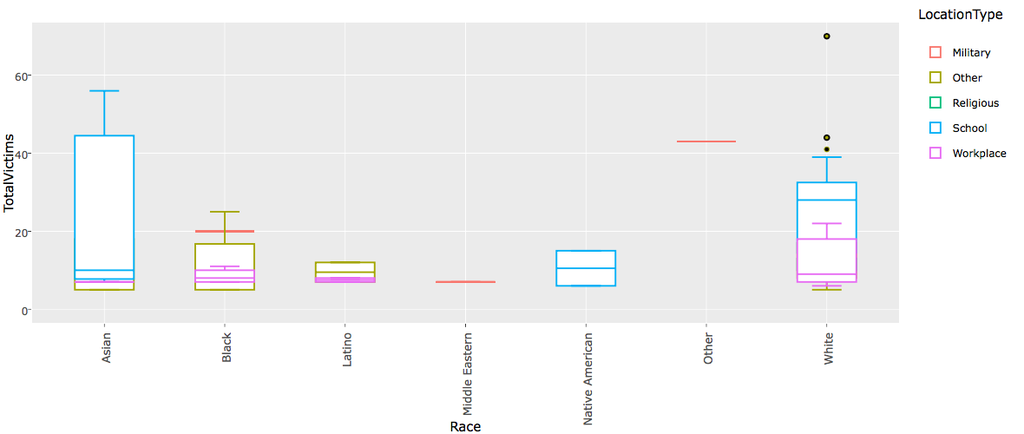

**Tableau Visualization**

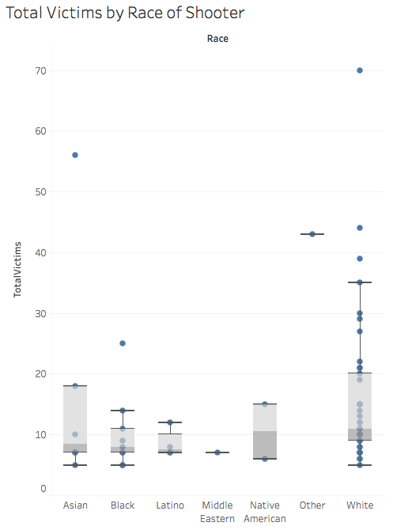

#### **Interesting observation(s)**

One interesting observation seen from this visualization is the significantly high number of data points in the White column. Total victims in this column also appear to be higher relative to other races, contrary to some current public assumptions (i.e. “black on black violence”, “middle-eastern terrorists, etc.)

### **Visualization 2: Histogram**

The following is a histogram of the number of legal weapons carried (x axis) versus the count of instances a shooting occured with the # of weapons. This histogram is filtered by cases of prior mental illnesses (true) and the legality of the weapons (true).

**Shiny Visualization**

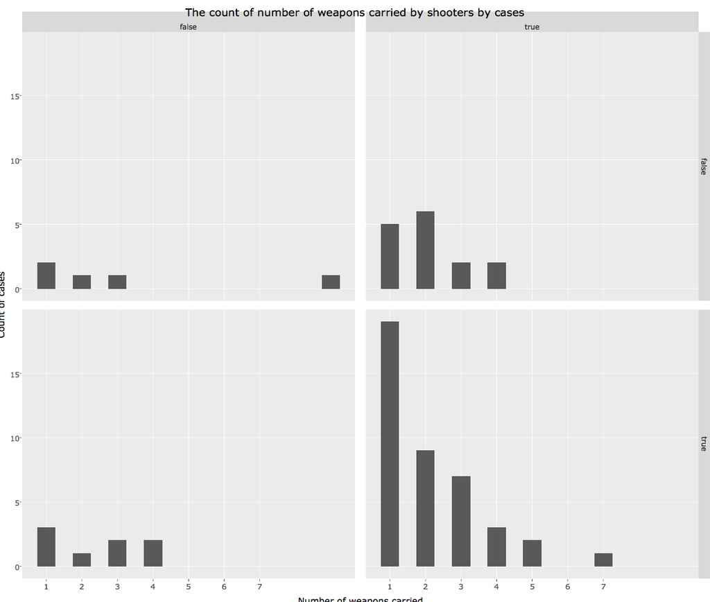

**Tableau Visualization**

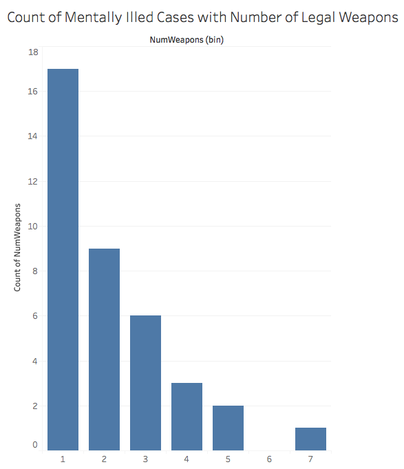

#### **Interesting observation(s)**

One interesting observation from this visualization is the shocking number of people being approved for firearms while having a prior mental illness. This may provide further interpretation on our current gun laws.

### **Visualization 3: Scatterplot**

The following is a scatterplot of the number of fatalities per incident (x axis) versus the number of weapons (y axis, legality does not matter), colored by the type of location the shooting occured (military, other, religious, school, workplace).

**Shiny Visualization**

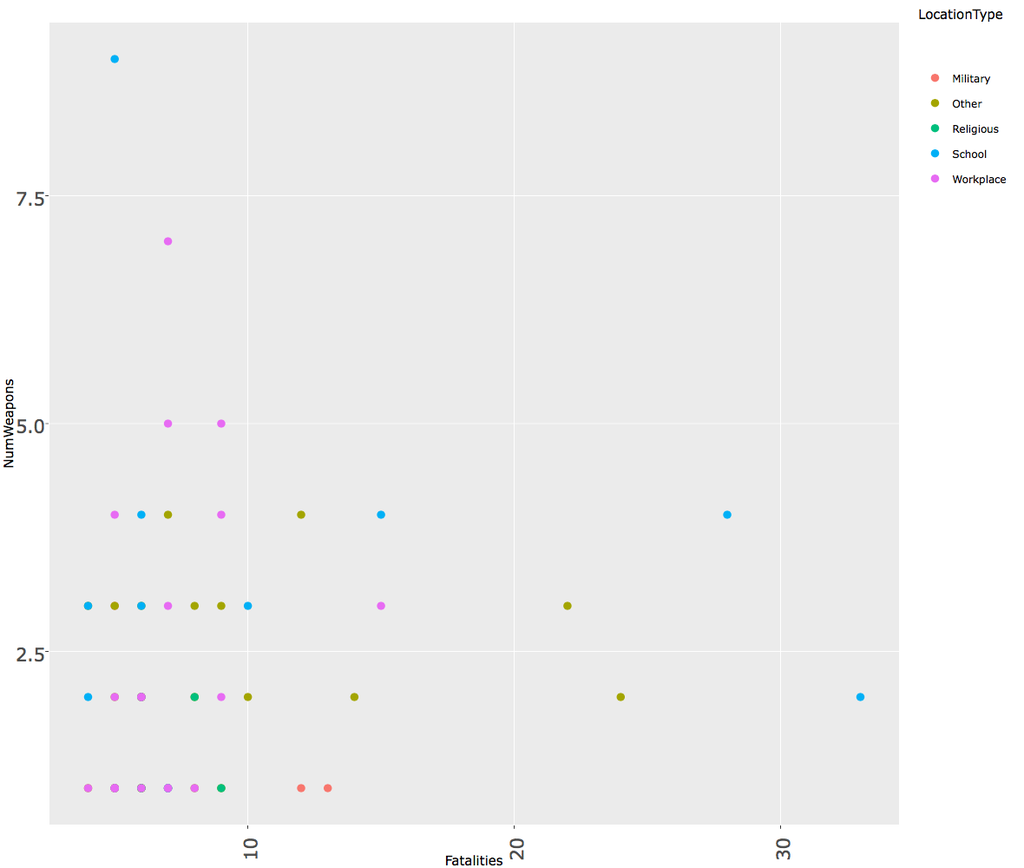

**Tableau Visualization**

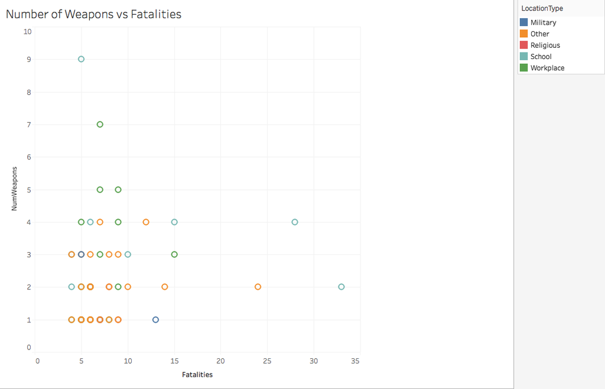

#### **Interesting observation(s)**

One interesting observation of this visualization is the alarming fact of the data located around the top left corner (high number of weapons, low fatalities). Even though the fatality count was low, further observations could be made on how these data points are mainly school and workplace areas, which brings concern to how these weapons entered these premises (in such quantities).

### **Visualization 4: Crosstabs**

**Shiny Visualization**

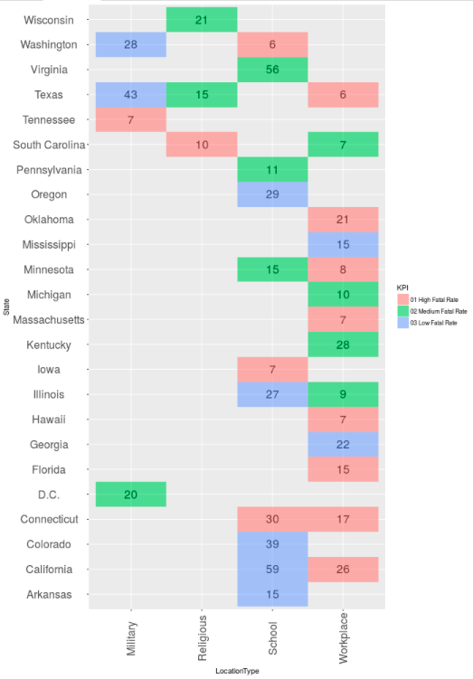

**Tableau Visualization**

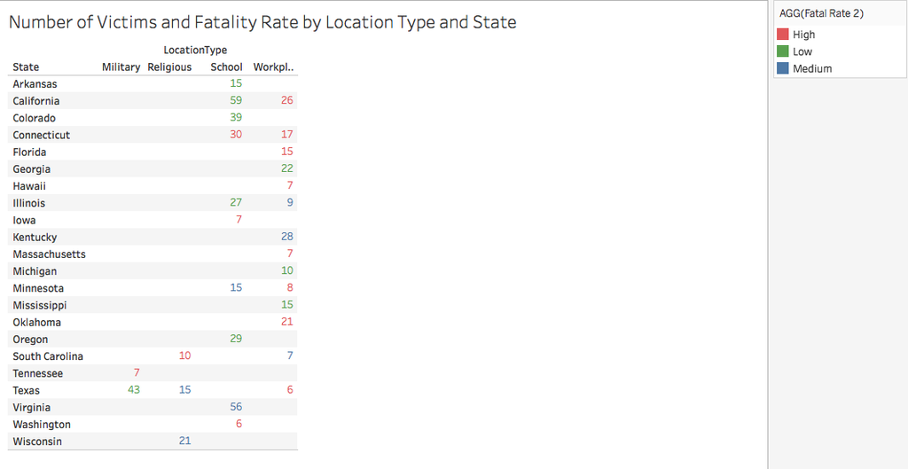

#### **Interesting observation(s)**

One interesting observation of this visualization is the fact that a relatively large amount of shootings (of all categories) are occuring in the workplace and the school areas. This could lead to the observation that more people “snap” in these areas(which suggests for more mental health counseling services), or possibly these places are “popular” areas to start violent incidents (which suggests for more security).

### **Visualization 5: Barcharts**

The following is barcharts of number of victims by race and location type (categorized under race). Average lines for each race are present to compare each location type to the average within each window and also to compare the averages among races.

**Shiny Visualization**

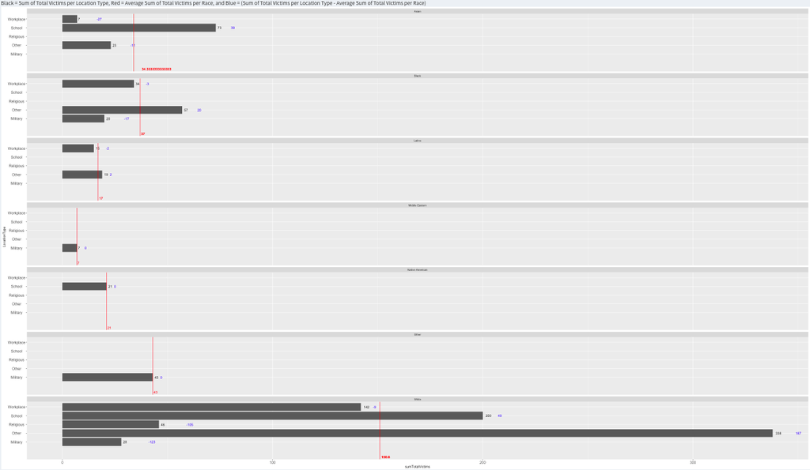

**Tableau Visualization**

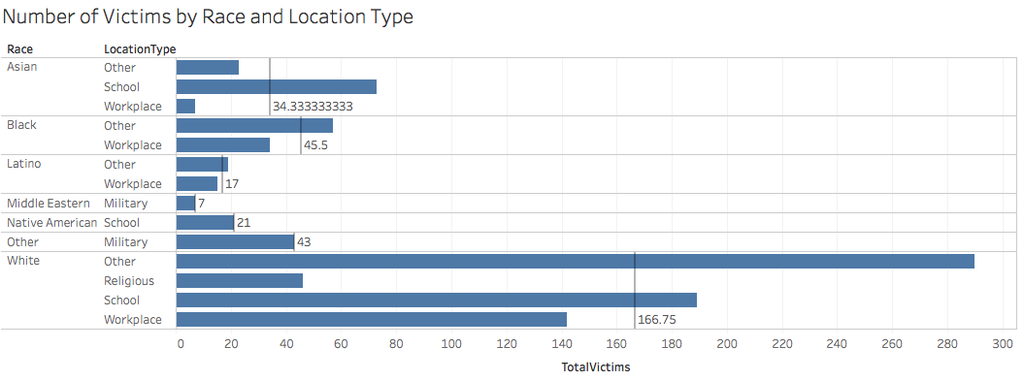

#### **Interesting observation(s)**

One interesting observation is how one incident can skew the averages due to low sample size. For example, the Virginia Tech massacre with 56 total victims is primarily responsible for the high average among the Asian group.

### **Visualization 6: Map**

The following is a map of the mass shooting cases that occurred during the years when total fatalities exceeded 35. Only four years met the condition within this timeframe, 1999, 2007, 2009, and 2012. The size of the data points reflect the number of fatalities in each case.

**Map Visualization (United States)**

[figure not shown]

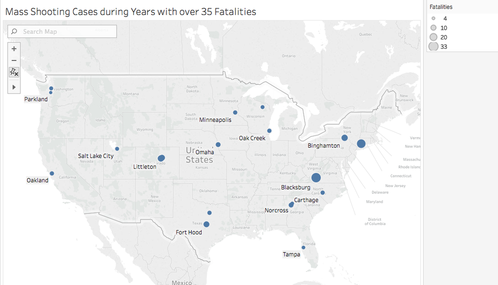

**Map Visualization (Hawaii)**

[figure not shown]

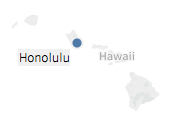

**Map Visualization (Reference Map)**

[figure not shown]

#### **Interesting observation(s)**

An interesting observation is how common mass shootings occur in or near densely populated areas, when comparing the visualization we created to a chloropleth map of population density above.

# **Instructions on Creating the Visualizations on Tableau**

### **Boxplot**

To create this visualization, we dragged *Race* to Columns and *TotalVictims* to Rows. If *sum(TotalVictims)* is in Rows, turn off Aggregate Measures by clicking on Analysis and uncheck Aggregate Measures.

### **Histogram**

The histogram below was created by first generating bins by right-clicking *NumWeapons* -> Create -> Bins. Set the bin width to 1. Drag the newly created bins to Columns. Drag *NumWeapons* to Rows. Right-click *NumWeapons* -> Measure -> Count. We filtered by dragging *MentalIllness* and *LegalWeapon* to Filters and selecting True for both.

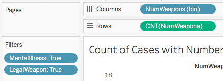

### **Scatterplot**

The scatterplot was made by dragging *Fatalities* to Columns and *NumWeapons* to Rows. *LocationType* is dragged to Color to fill each circle with color of the corresponding location type.

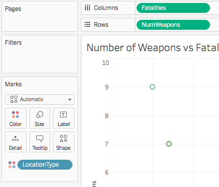

### **Crosstabs**

The crosstabs were made by dragging *LocationType* to Columns and *State* to Rows. *TotalVictims* was dragged to Text. We colored the text with a calculated field, *Fatal Rate*. The image below shows the calculation.

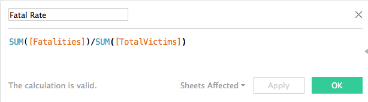

In order to group the fatal rates into low, medium, and high categories, we created parameters such as the one below. Low ranged from 0 to 0.5. Medium ranged from 0.5 to 0.7. and High ranged from 0.7 to 1.

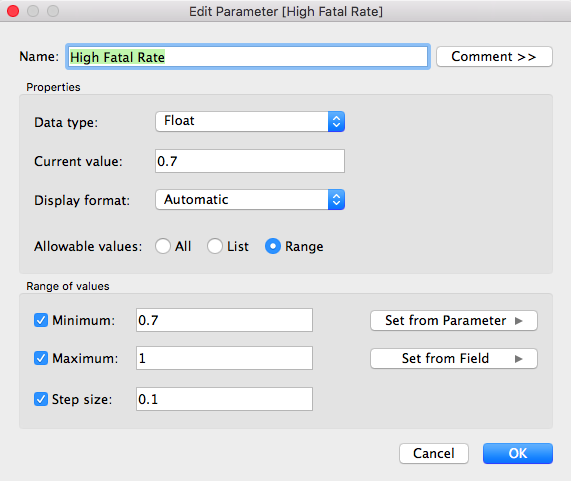

A new field, *Fatal Rate 2* was created to assign each fatal rate to a qualitative measure rather than quantitative. The calculation is shown below.

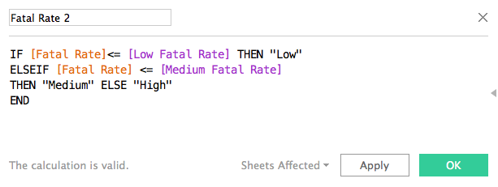

*Fatal Rate 2* is dragged to Color. We also filtered out the Other type by dragging *LocationType* to Filters and deselecting Other.

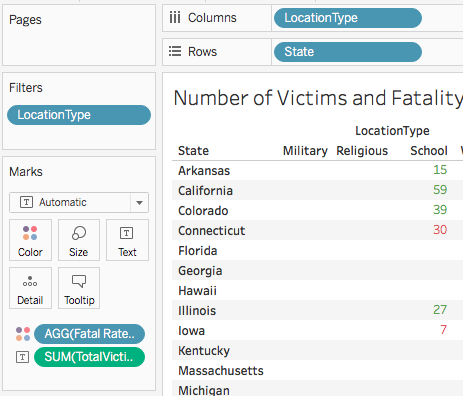

### **Barcharts**

The barcharts were made by dragging *TotalVictims* to Columns, and *Race* and *LocationType* to Rows. Average lines were inserted by clicking on the Analytics Tab and double clicking on Average Line.

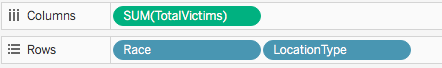

### **Map**

This map was made by converting *Latitude* and *Longitude* to geographic types by right-clicking them -> Geographic Role -> Latitude (Longitude), then dragging them to Rows and Columns, respectively. We filtered out years when the number of fatalities totaled less than 35, by dragging Year to Filters and selecting 1999, 2007, 2009, and 2012. To add information to the data points, we dragged *City*, *State*, and *Case* to Detail. We varied the sizes of each point by dragging *Fatalities* to Size.

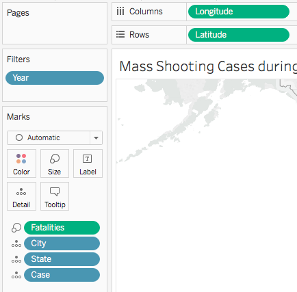